# Algorithm Class - Practice 2 - Classes, objects, and references (II)

2018/7/1

# Java “Hello World” 2: The more you should know

```java
public class Student {
  public int age;  //(member) field
  private final String name;  //(constant) field
  private static String school;  //(static) field
  private static final String GREETINGS = "Hello";  //(static constant) field

  public Student(String name) {  //Constructor
    this.name = name;  //name = n;
  }

  //Unlike C++, Java has no destructor (relying on GC)

  public int getAge() {  //(member) method, getter, accessor
    return age;
  }

  public void setAge(int age) {  (member) method, setter
    this.age = age;
  }

  public String getName() {  //(member) method, getter, accessor
    return name;
  }

  public void sayHello() {  //(member) method
    System.out.println(GREETINGS + "! I am " + name + ". I am " + age);
  }
}
```

```java
public class HelloWorld {
  public static void main(String[] args) {
    Student firstStudent = new Student("Tom");
    Student secondStudent = new Student("Jerry");
    Student thirdStudent = null;
    firstStudent.setAge(18);
    secondStudent.setAge(10);
    firstStudent.sayHello();
    secondStudent.sayHello();
    Student fourthStudent = null;
    try {
      thirdStudent.sayHello();
    } catch (NullPointerException e) {
      System.out.println("Expected error occured! - " + e.toString());
    }
  }
}
```

# Static

Members (fields, methods, classes) belong to class, not object. [link](https://stackoverflow.com/questions/413898/what-does-the-static-keyword-do-in-a-class)

What do you mean by “belong to class, not instance”?

```java
LaiOfferManager sunLaoShi = new LaiOfferManager();
sunLaoShi.name = "Sun";
sunLaoShi.salary = 9999999;
LaiOfferManager zhaoLaoShi = new LaiOfferManager();
zhaoLaoShi.name = "Zhao";
zhaoLaoShi.salary = 1000000;
```

Each teacher has one’s own name and salary.

```java
LaiOfferManager.meetingSoftware = new Zoom();
LaiOfferManager.isRich = false;
```

Note: we do not need an instance to access those (static) fields. These fields belong to the class.

```java
public class LaiOfferManager {
  public static void ipo() {
    isRich = true;
  }
}
//...
LaiOfferManager.ipo();
```

The behavior `ipo()` also belong to the whole class, but not any instance. Of course, it can only operate fields that belong to the class, but not instances (static fields).

**Class variable vs. Instance variable / Class method vs. Instance method**

```java
public class Solution {
  static int result = 0;
  public void sort() {
    //...
  }
  public static void main(String[] args) {
    Solution s = new Solution();
    s.sort();
    System.out.println("The result is: " + s.result);
  }
}

Solution.main();
```

# Fianl

Constants. “Once assigned, cannot be changed.”  
Final **class**: A class that cannot be derived.  
Final **method**: A method that cannot be overridden.  
Final **field**: A variable that once assigned, cannot be assigned again.

Enforced invariance, instead of this:

```java
//Do not change the value!
int value = 5;
```

What is the implication of this?

```java
public class BoyStudent extends Student {
  //...
  final Student girlFriend;
  public BoyStudent(Student gf) {
    girlFriend = gf;
  }
  //...
}
```

Can we do this?

```java
Boy b = new Boy(new Girl("taylor"));
b.girlFriend = new Girl("gaga");
```

Or this?

```java
Boy b = new Boy(new Girl("taylor"));
b.girlFriend.setName("gaga");
```

Draw the object layout and figure out which part is final.

# Exercise

If we’re design a class for cars, how should we design it?

A Tesla Model S car may have:

- Brand
- Model
- Year
- Mileage
- Plate number
- Color
- Owner’s name

Think:

1. What should be final?
2. Can you come up some states that belong to all cars? How should you annotate them?

A car may:

- Drive
- Change owner
- …

Think:

- Will some behaviors change any states? If so, can you write something? Can you come up with some states that belong to all cars? How should you represent them?

# Java Parameter Passing

What is parameter passing?

```java
void foo(int a) {
  System.out.println(a * a);
}
//...
foo(5);
//...
```

We are passing int value 5 to method foo(int).

How to actually “pass”?

- Java is always pass by value (copy)
  - primitive type: **copy** of the **value itself**
  - objects: **copy** of the object **reference**

What is the implication?

```java
public class Simple {
  public int value;
  public Simple(int v) {
    value = v;
  }
}
```

```java
public class ChangeTest {
  public static void main(String[] args) {
    Simple originalSimple = new Simple(5);
    changeSimpleValue1(originalSimple);
    System.out.println(originalSimple.value);

    Simple originalSimple = new Simple(5);
    changeSimpleValue2(originalSimple);
    System.out.println(originalSimple.value);

    Simple originalSimple = new Simple(5);
    originalSimple = changeSimpleValue3(originalSimple);
    System.out.println(originalSimple.value);

    int x = 5;
    changeIntValue(x);
    System.out.println(x);
  }
  private static void changeIntValue(int x) {
    x = 10;
  }

}
```

In changeSimpleValue1:

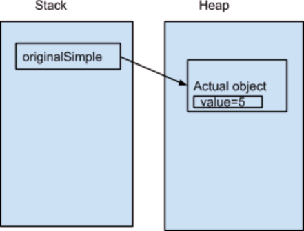

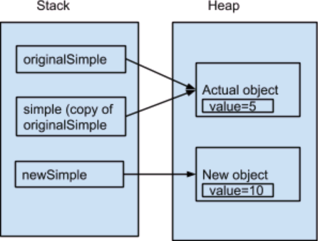

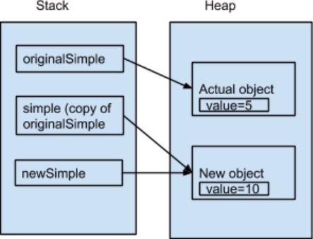

In changeSimpleValue2:

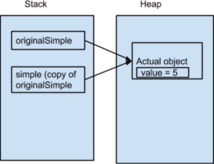

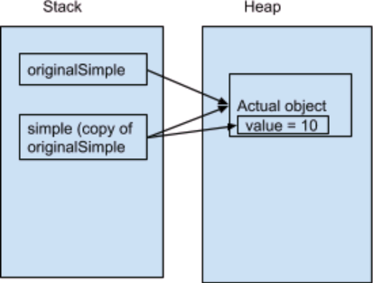

In changeSimpleValue3:

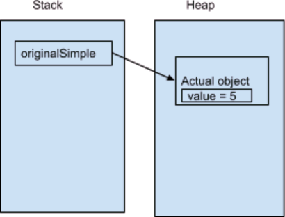

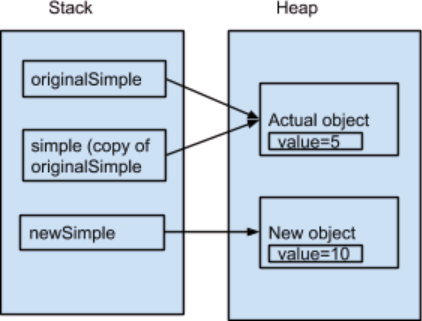

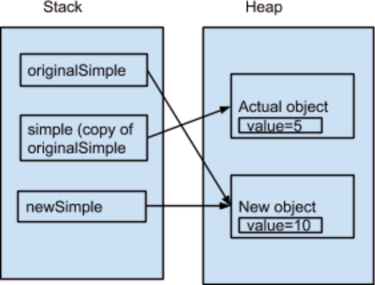

# Array vs. Objects

What are arrays in Java? How are they stored in memory?

- arrays are **Objects**
- I can not find the class for arrays…
  - True, the class declaration is not visible, but there still exists a class inside JVM.
  - each of the arrays created is an instance of that class.
  - remember “**new**” - it implies that there is a new object created.
- the elements in the array still occupy consecutive memory space on the heap
- **“length” is a field of the array object**
- **array length cannot be changed after the array object is created. (final)**

```java
int[] array = new int[3];
```

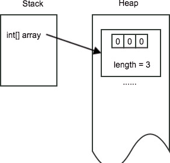

```java
int[][] array = new int[2][];
array[0] = new int[1];
array[1] = new int[3];

int[][] array = new int[2][3];
int[][] array = {{1, 2}, {3, 4}};
```

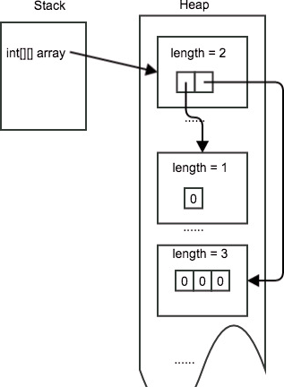

Occupies consecutive memory and the elements in the array can be referenced via the index in O(1) time.

```java
int[] array = new int[3];  //{0, 0, 0}

int[] array = {1, 2, 3};  //{1, 2, 3}
int[] array = new int[]{1, 2, 3, 4, 5};  //{1, 2, 3, 4, 5}

int[] array;
array = new int[]{1, 2, 3};  //{1, 2, 3}
```

**Exceptions/Errors:**

- **ArrayIndexOutOfBoundException!**
  - If the index specified is not in the valid range of the array

```java
int[] array = new int[]{5};  //array = new int[5];
int value = array[5];
```

- **NullPointerException!**

```java
int[] array = null;
int value = array[1];

int[][] array = new int[5][];  //{null, null, null, null, null}
int[] v1 = array[6];  //ArrayIndexOutOfBoundException!
int v2 = array[3][2];  //NullPointerException!
```